# HW2

#1(a) The inverse method

將cdf微分變成pdf，再做反函數。 生成uniform（0，1）隨機變數丟到inverse_f生成分配（如圖，cdf，黑線）。

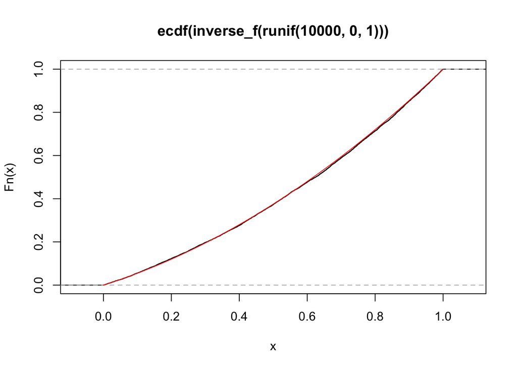

```r
Fx<-function(x){
  return (0.5*(x+x^2))
}
range_f <- seq(0,1,by=0.01)
inverse_f<-function(y){
  return((2*(y+0.125))^0.5-0.5)
}
plot(ecdf(inverse_f(runif(10000,0,1)))) #自己生的
lines(seq(0,1,length.out = 100),Fx(seq(0,1,length.out = 100)),col="red") #原本的
```

紅線為原本題目給的cdf

#1(b) Accepance method

設定function，並找出容易抽的function fy（pdf），做出fy的cdf —— Fy，寫成inverse function —— inverse_G。

```r
Fx<-function(x){
  return (0.5*(x+x^2))
}
fx<-function(x){
  return (x+0.5)
}
range_f <- seq(0,1,by=0.01)

fy<-function(x){
  return((2/3)*(1+x))
}
inverse_G <- function(y){ #cdf
  return ((3*(y+1/3))^0.5-1)
}
```

找出c值，並先建立空間f_x，生成1隨機變數x～uni（0,1)， 再重新生成隨機變數U～uni(0,1)，如果U<=fx(x)/(c*fy(x))，就再已開好的空間f_x中，將0設為x，repeat10000次。

```r
c <-max(fx(range_f)/fy(range_f))
c
```

```
## [1] 1.125
```

```r
f_x <-rep(0,10000)
i = 1
repeat{
  x<-inverse_G(runif(1,0,1))
  if(runif(1,0,1)<=fx(x)/(c*fy(x))){
    f_x[i] = x
    i = i+1
    }
  if(i == 10001){break}
}
```

黑色線為自己生成的函數的cdf，紅線為題目給定cdf，確定抽出來的fy經調整後可以近似原題目給定分配。

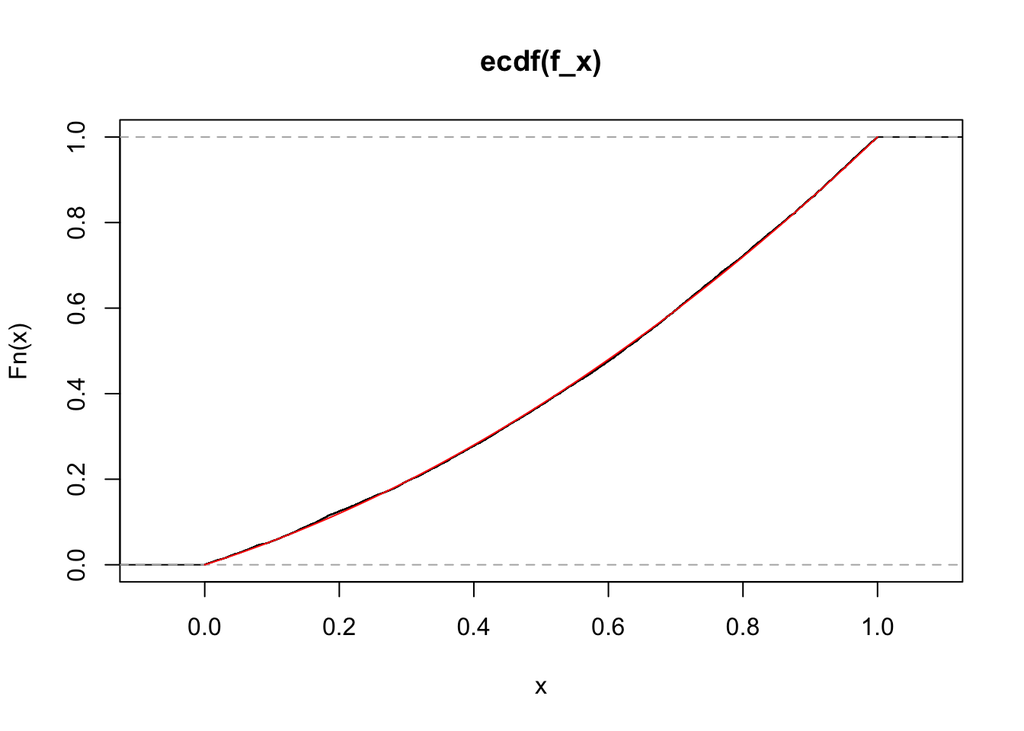

```r
plot(ecdf(f_x)) #generated cdf one
lines(seq(0,1,length.out = 100),Fx(seq(0,1,length.out = 100)),col="red") #given cdf one
```

#1(c)Composition Method

將fx拆成2個distribution，分別為g1=1,g2=2x，權重p1=0.5,p2=0.5。 註：g1～uni（0,1)，g2的cdf-inverse設為inverse_G2。

```r
g1<- function(x){
  return(1)
}
g2 <- function(x){
  return(2*x)
}
G2<-function(x){
  return (x^2)
}
inverse_G2<-function(y){
  return(sqrt(y))
}
```

生成隨機變數U1～uni(0,1)， 開好空間vec， 如果 0<=U1<0.5，則將vec中該位置的0以另外生成的隨機數字～uni(0,1)取代，註：因為g1=1，為uni(0,1)。 如果U1落在另外一半，則將vec中該位置的0，生成隨機數字放入g2分配，並取代。

```r
U1<-runif(10000,0,1)
vec = numeric(10000)
for(i in 1:10000){
  if(0<=U1[i] &&U1[i]<0.5){
    vec[i] = runif(1,0,1)
  }else{
    vec[i] = inverse_G2(runif(1,0,1))
  }
}
```

黑線為以composition method 生成的cdf， 紅色為題目給定function cdf。

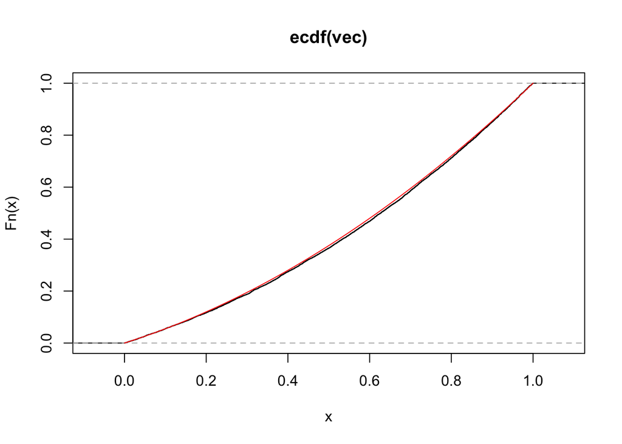

```r
plot(ecdf(vec))
lines(seq(0,1,length.out = 100),Fx(seq(0,1,length.out = 100)),col="red")
```

#2(a)Acceptance-rejection Method Fx：題目給定cdf。 fx：題目的pdf。 fy：比較好抽的分配pdf。 inverse_G：fy的cdf-inverse。

```r
Fx<-function(x){
  return (1-exp(-x)-exp(-2*x)+exp(-3*x))
}
fx<-function(x){
  return (exp(-x)+2*exp(-2*x)-3*exp(-3*x))
}
range_f <- seq(0,1,by=0.01)

fy<-function(x){
  return(exp(-x))
}
inverse_G <- function(y){ #cdf
  return (-log(y))
}
```

求出c

```r
c <-max(fx(range_f)/fy(range_f))
c
```

```
## [1] 1.329753
```

f_x：先開好的空間。 x:隨機生成數字丟如inverse_G。 再生成隨機～uni(0,1)<=fx(x)/(c*fy(x))，則在f_x中該位置以x取代0。 註：以上動作做10000次

```r
f_x <-rep(0,10000)
i = 1
repeat{
  x<-inverse_G(runif(1,0,1))
  if(runif(1,0,1)<=fx(x)/(c*fy(x))){
    f_x[i] = x
    i = i+1
  }
  if(i == 10001){break}
}
```

黑色線為自己生成的函數的cdf，紅線為題目給定cdf，確定抽出來的fy經調整後可以近似原題目給定分配。

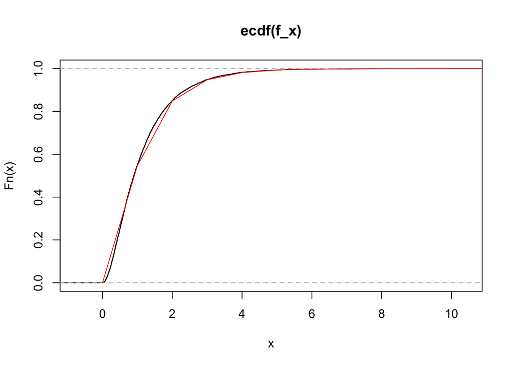

```r
plot(ecdf(f_x))
lines(seq(0,,length.out = 100),Fx(seq(0,,length.out = 100)),col="red")
```

#2(b) 找Fx的inverse function，令Fx-a=0，其中a為原本y的域（0<a<1)。給定a後利用uniroot解出x值，在此利用a～uni(0,1)，生成10000筆，解出對應x值。

```r
Fx<-function(x){
  return (1-exp(-x)-exp(-2*x)+exp(-3*x))
}
f <- function(x,a){
  return (1-exp(-x)-exp(-2*x)+exp(-3*x)-a)
}

U1<-runif(10000,0,1)
vec = numeric(10000)
for(i in 1:10000){
  root<-uniroot(f,interval = c(0,100),a = U1[i])$root
  vec[i]<-root
}
```

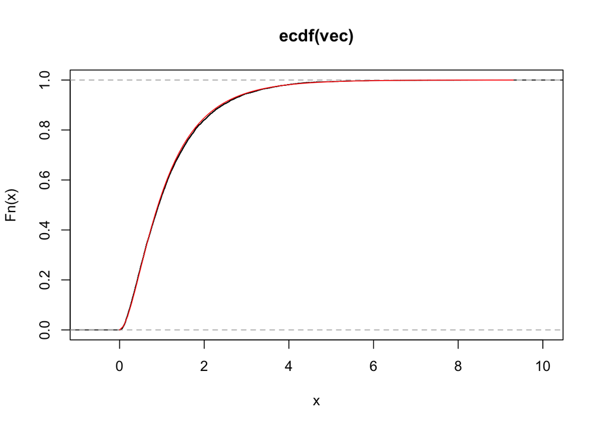

```r
plot(ecdf(vec))
lines(seq(0,max(vec),length.out = 100),Fx(seq(0,max(vec),length.out = 100)),col="red")
```

#3(a) Acceptance-rejection Method

fx：題目給定的pdf。 fy：比較好抽，調整後用來模擬fx的分配。 inverse_G:fy轉換成cdf後的inverse function。 Fx:題目的cdf。

```r
fx<-function(x){
  return (0.25+2*x^3+1.25*x^4)
}
range_f <- seq(0,1,by=0.01)
Fx<-function(x){
  return (0.25*x+0.5*x^4+0.25*x^5)
}
fy<-function(x){
  return(5/31*(x+1)^4)
}
inverse_G <- function(y){ #cdf
  return ((31*(y+1/31))^(1/5)-1)
}
```

找出c

```r
c <-max(fx(range_f)/fy(range_f))
c
```

```
## [1] 1.55
```

f_x：先開好的空間。

x:隨機生成數字丟如inverse_G， 再生成隨機～uni(0,1)<=fx(x)/(c*fy(x))，則在f_x中該位置以x取代0。 註：以上動作做10000次

```r
f_x <-rep(0,10000)
i = 1
repeat{
  x<-inverse_G(runif(1,0,1))
  if(runif(1,0,1)<=fx(x)/(c*fy(x))){
    f_x[i] = x
    i = i+1
  }
  if(i == 10001){break}
}
```

黑色線為自己生成的函數的cdf，紅線為題目給定cdf，確定抽出來的fy經調整後可以近似原題目給定分配。

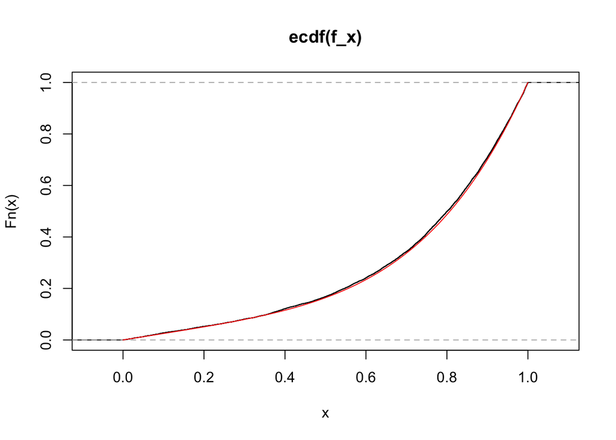

```r
plot(ecdf(f_x))
lines(seq(0,1,length.out = 100),Fx(seq(0,1,length.out = 100)),col="red")
```

#3(b) Composition Method 將pdf拆成3個distribution ——g1,g2,g3，權重分別為0.25，0.5，0.25。 並將g2,g3 做成cdf後取inverse function，分別為inverse_G2，inverse_G3。 註：因g1=1，cdf inverse後為uni(0,1)

```r
g1<- function(x){
  return(1)
}
g2 <- function(x){
  return(4*x^3)
}
g3 <- function(x){
  return(5*x^4)
}
inverse_G2<-function(y){
  return(y^(0.25))
}
inverse_G3<-function(y){
  return(y^(0.2))
}
```

生成隨機變數U1～uni(0,1)， 開好空間vec， 如果 0<=U1<0.25，則將vec中該位置的0以另外生成的隨機數字～uni(0,1)取代，註：因為g1=1，為uni(0,1)。 如果0.25<=U1<0.75，則將vec中該位置的0，生成隨機數字放入g2分配，並取代。 如果0.75<=U1<0.1，則將vec中該位置的0，生成隨機數字放入g3分配，並取代。

```r
U1<-runif(10000,0,1)
vec = numeric(10000)
for(i in 1:10000){
  if(0<=U1[i] &&U1[i]<0.25){
    vec[i] = runif(1,0,1)
  }else if(0.25<=U1[i] &&U1[i]<0.75){
    vec[i] = inverse_G2(runif(1,0,1))
  }else{
    vec[i] = inverse_G3(runif(1,0,1))
  }
}
```

黑線為以composition method 生成的cdf， 紅色為題目給定function cdf。

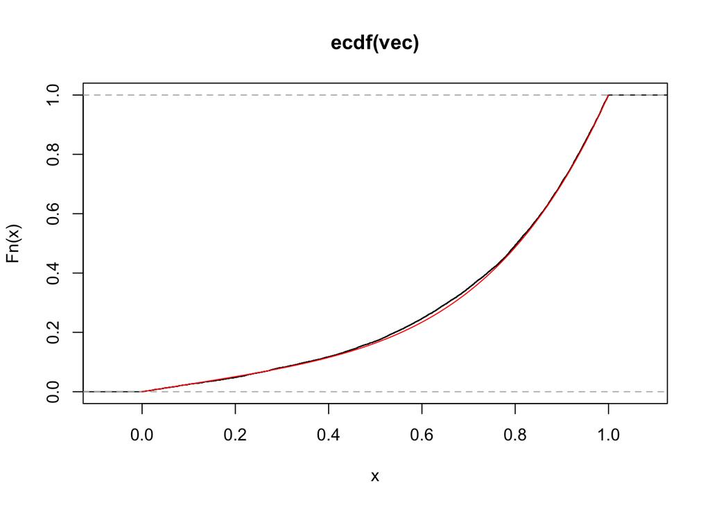

```r
plot(ecdf(vec))
lines(seq(0,1,length.out = 100),Fx(seq(0,1,length.out = 100)),col="red")
```